# Week 5

Heidi Hautakangas

# WEEK 5

## ANALYSIS

HUMAN data set contains 8 variables and 155 observations, each observation representing one country. Original Human data is collected for calculating Human Development index, which is a summary measure, a geometric mean of normalized indices for achievements in three dimensions of human development, which are a long and healthy life, access to knowledge and a decent standard of living. More information can be found:

http://hdr.undp.org/en/content/human-development-index-hdi

Short description of the variables:

- Health and knowledge

-“GNI” = Gross National Income per capita

-“Life.Exp” = Life expectancy at birth

-“Edu.Exp” = Expected years of schooling

-“Mat.Mor” = Maternal mortality ratio

-“Ado.Birth” = Adolescent birth rate

- Empowerment

-“Parli.F” = Percentage of female representatives in parliament

-“Edu2.FM” = ratio between the proportion of females and males with at least secondary education

-“Labo.FM” = ratio between the proportion of females and males in the labour force

```r
# read mutated HUMAN data into R
HUMAN <- read.table("data/human.txt", as.is=T, header=T)
# structure, dimension and summary
str(HUMAN)
```

```
## 'data.frame':    155 obs. of  8 variables:
##  $ Edu2.FM  : num  1.007 0.997 0.983 0.989 0.969 ...
##  $ Labo.FM  : num  0.891 0.819 0.825 0.884 0.829 ...
##  $ Edu.Exp  : num  17.5 20.2 15.8 18.7 17.9 16.5 18.6 16.5 15.9 19.2 ...
##  $ Life.Exp : num  81.6 82.4 83 80.2 81.6 80.9 80.9 79.1 82 81.8 ...
##  $ GNI      : int  64992 42261 56431 44025 45435 43919 39568 52947 42155 32689 ...
##  $ Mat.Mor  : int  4 6 6 5 6 7 9 28 11 8 ...
##  $ Ado.Birth: num  7.8 12.1 1.9 5.1 6.2 3.8 8.2 31 14.5 25.3 ...
##  $ Parli.F  : num  39.6 30.5 28.5 38 36.9 36.9 19.9 19.4 28.2 31.4 ...
```

```r
dim(HUMAN)
```

```
## [1] 155   8
```

```r
summary(HUMAN)
```

```
##     Edu2.FM          Labo.FM          Edu.Exp         Life.Exp
##  Min.   :0.1717   Min.   :0.1857   Min.   : 5.40   Min.   :49.00
##  1st Qu.:0.7264   1st Qu.:0.5984   1st Qu.:11.25   1st Qu.:66.30
##  Median :0.9375   Median :0.7535   Median :13.50   Median :74.20
##  Mean   :0.8529   Mean   :0.7074   Mean   :13.18   Mean   :71.65
##  3rd Qu.:0.9968   3rd Qu.:0.8535   3rd Qu.:15.20   3rd Qu.:77.25
##  Max.   :1.4967   Max.   :1.0380   Max.   :20.20   Max.   :83.50
##       GNI            Mat.Mor         Ado.Birth         Parli.F
##  Min.   :   581   Min.   :   1.0   Min.   :  0.60   Min.   : 0.00
##  1st Qu.:  4198   1st Qu.:  11.5   1st Qu.: 12.65   1st Qu.:12.40
##  Median : 12040   Median :  49.0   Median : 33.60   Median :19.30
##  Mean   : 17628   Mean   : 149.1   Mean   : 47.16   Mean   :20.91
##  3rd Qu.: 24512   3rd Qu.: 190.0   3rd Qu.: 71.95   3rd Qu.:27.95
##  Max.   :123124   Max.   :1100.0   Max.   :204.80   Max.   :57.50
```

Data summary shows that there are very diverse scales between variables, so standardizing the data set would be useful for many analysis.

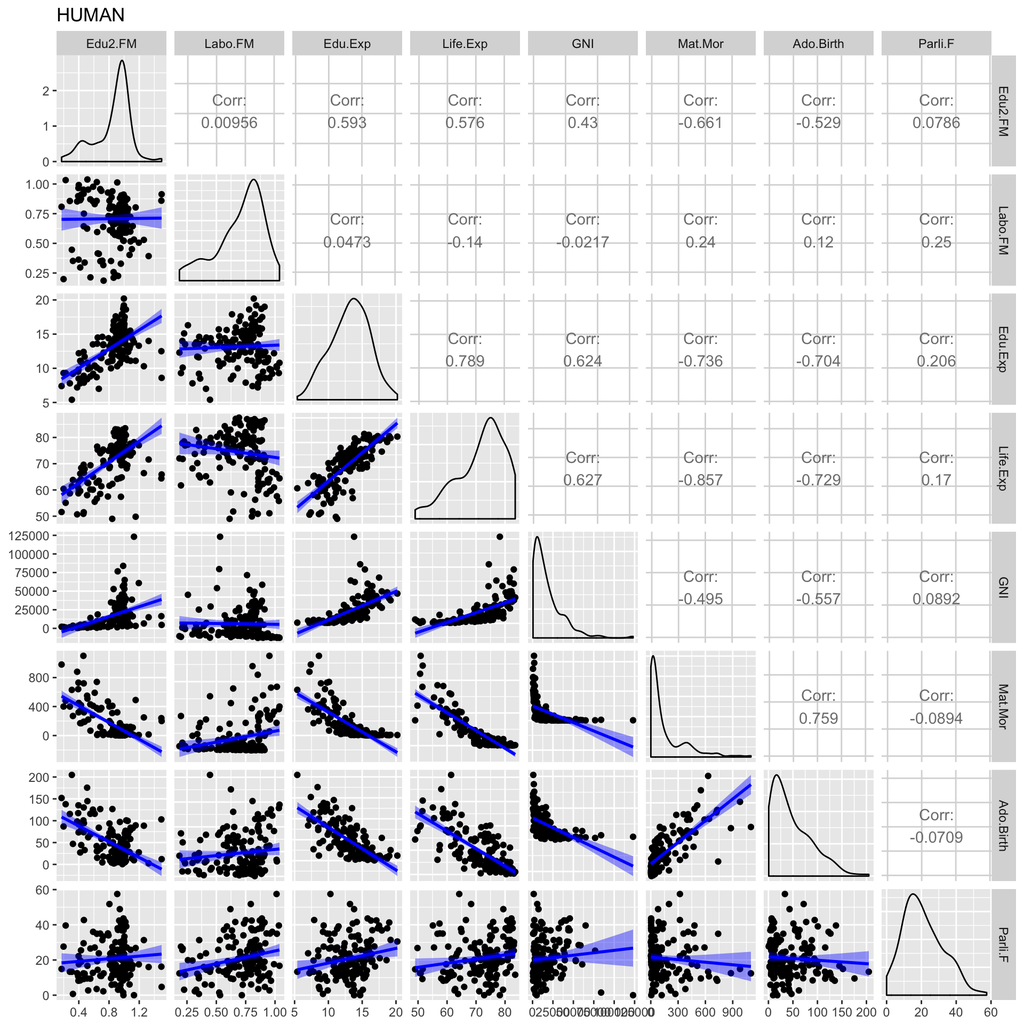

```r
# Plots
# function for regression lines
my_fn <- function(data, mapping, ...){
  p <- ggplot(data = data, mapping = mapping) +
    geom_point() +
    geom_smooth(method=lm, fill="blue", color="blue", ...)
  p
}

g = ggpairs(HUMAN,columns = 1:8, lower = list(continuous = my_fn))
p1 <- g + ggtitle("HUMAN")
p1
```

Figure 1. Human data

Figure 1 shows that most of the variables are skewed: ratio between the proportion of females and males with at least secondary education (Edu2.FM), ratio between the proportion of females and males in the labour force (Labo.FM), and life expectancy at birth (Life.exp) are clearly left skewed and Gross National Income per capita (GNI), maternal mortality ratio (Mat.Mor), adolescent birth rate (Ado.Birth) and percentage of female representatives in parliament (Parli.F) right skewed. Only expected years of schooling (Edu.Exp) seems to follow normal distribution. There seems to be strong positive correlation between expected years of schooling and life expectancy at birth, and also between GNI and both expected years of schooling and life expectancy at birth. There is strong negative correlation between maternal mortality ratio and the ratio between the proportion of females and males with at least secondary education, as well as between life expectancy at birth and maternal mortality ratio. These can be observed also from the correlation plot below (Figure 2.)

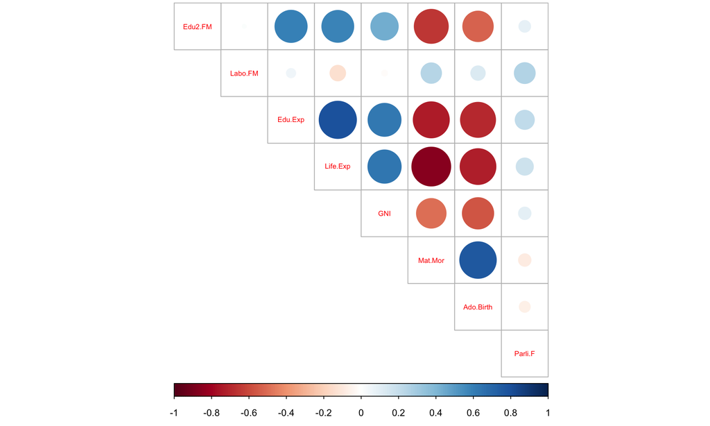

```r
# correlation plot
cor_matrix<-cor(HUMAN) %>% round(2)
corrplot(cor_matrix, method="circle", type="upper", cl.pos="b", tl.pos="d",tl.cex=0.6)
```

Figure 2. Correlation plot

### Principal Component Analysis (PCA)

Principal component analysis is a dimension reduction technique which aims to find those components from the data that describes the data best without losing any important information. First principal component captures most of the variance, and then second principal component most of the remaining variance and it is orthogonal to the first PC. Each principal component are uncorrelated.

At first, PCA is performed for unstandardized dataset. Results can be seen below. In this case, because the data is unstandardized, first principal component captures all the variation because there are so much differences between the scales of the variables. PC2 contains only 0.0001 from the variance. Figure 3 shows how most of the observations are located in the upper right corner. This is not very informative analysis, so next the variables are standardized and PCA repeated.

```r
# PC 1
pca_hum1 <- prcomp(HUMAN)
pca_hum1
```

```
## Standard deviations:
## [1] 1.854416e+04 1.855219e+02 2.518701e+01 1.145441e+01 3.766241e+00
## [6] 1.565912e+00 1.912052e-01 1.591112e-01
##
## Rotation:
##                     PC1           PC2           PC3           PC4
## Edu2.FM   -5.607472e-06  0.0006713951 -3.412027e-05 -2.736326e-04
## Labo.FM    2.331945e-07 -0.0002819357  5.302884e-04 -4.692578e-03
## Edu.Exp   -9.562910e-05  0.0075529759  1.427664e-02 -3.313505e-02
## Life.Exp  -2.815823e-04  0.0283150248  1.294971e-02 -6.752684e-02
## GNI       -9.999832e-01 -0.0057723054 -5.156742e-04  4.932889e-05
## Mat.Mor    5.655734e-03 -0.9916320120  1.260302e-01 -6.100534e-03
## Ado.Birth  1.233961e-03 -0.1255502723 -9.918113e-01  5.301595e-03
## Parli.F   -5.526460e-05  0.0032317269 -7.398331e-03 -9.971232e-01
##                     PC5           PC6           PC7           PC8
## Edu2.FM   -0.0022935252  2.180183e-02  6.998623e-01  7.139410e-01
## Labo.FM    0.0022190154  3.264423e-02  7.132267e-01 -7.001533e-01
## Edu.Exp    0.1431180282  9.882477e-01 -3.826887e-02  7.776451e-03
## Life.Exp   0.9865644425 -1.453515e-01  5.380452e-03  2.281723e-03
## GNI       -0.0001135863 -2.711698e-05 -8.075191e-07 -1.176762e-06
## Mat.Mor    0.0266373214  1.695203e-03  1.355518e-04  8.371934e-04
## Ado.Birth  0.0188618600  1.273198e-02 -8.641234e-05 -1.707885e-04
## Parli.F   -0.0716401914 -2.309896e-02 -2.642548e-03  2.680113e-03
```

```r
# summary of the results
pca_hum1b <- summary(pca_hum1)
pca_hum1b
```

```
## Importance of components:
##                              PC1      PC2   PC3   PC4   PC5   PC6    PC7
## Standard deviation     1.854e+04 185.5219 25.19 11.45 3.766 1.566 0.1912
## Proportion of Variance 9.999e-01   0.0001  0.00  0.00 0.000 0.000 0.0000
## Cumulative Proportion  9.999e-01   1.0000  1.00  1.00 1.000 1.000 1.0000
##                           PC8
## Standard deviation     0.1591
## Proportion of Variance 0.0000
## Cumulative Proportion  1.0000
```

```r
# rounded percetanges of variance captured by each PC
pca_pr <- round(100*pca_hum1b$importance[2, ], digits = 1)
pca_pr
```

```
## PC1 PC2 PC3 PC4 PC5 PC6 PC7 PC8
## 100   0   0   0   0   0   0   0
```

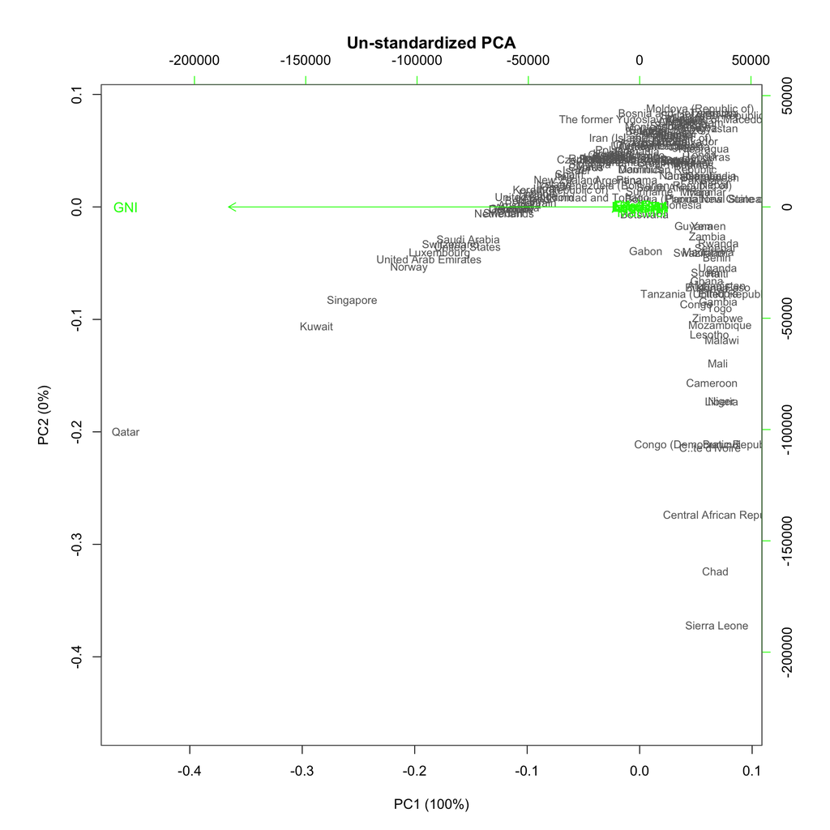

```r
# create object pc_lab to be used as axis labels
pc_lab <- paste0(names(pca_pr), " (", pca_pr, "%)")
#  biplot
biplot(pca_hum1, cex = c(0.8, 1), col = c("grey40", "green"), xlab = pc_lab[1], ylab =pc_lab[2], main="Un-standardized PCA")
```

Figure 3. Un-standardized PCA.

```r
# Scaling data
scal_hum <- scale(HUMAN)
#PCA 2
pca_hum2 <- prcomp(scal_hum)
pca_hum2b <- summary(pca_hum2)
#pca_hum2
pca_hum2b
```

```
## Importance of components:
##                           PC1    PC2     PC3     PC4     PC5     PC6
## Standard deviation     2.0708 1.1397 0.87505 0.77886 0.66196 0.53631
## Proportion of Variance 0.5361 0.1624 0.09571 0.07583 0.05477 0.03595
## Cumulative Proportion  0.5361 0.6984 0.79413 0.86996 0.92473 0.96069
##                            PC7     PC8
## Standard deviation     0.45900 0.32224
## Proportion of Variance 0.02634 0.01298
## Cumulative Proportion  0.98702 1.00000
```

```r
# rounded percetanges of variance captured by each PC
pca_pr2 <- round(100*pca_hum2b$importance[2, ], digits = 1)
# print out the percentages of variance
pca_pr2
```

```
##  PC1  PC2  PC3  PC4  PC5  PC6  PC7  PC8
## 53.6 16.2  9.6  7.6  5.5  3.6  2.6  1.3
```

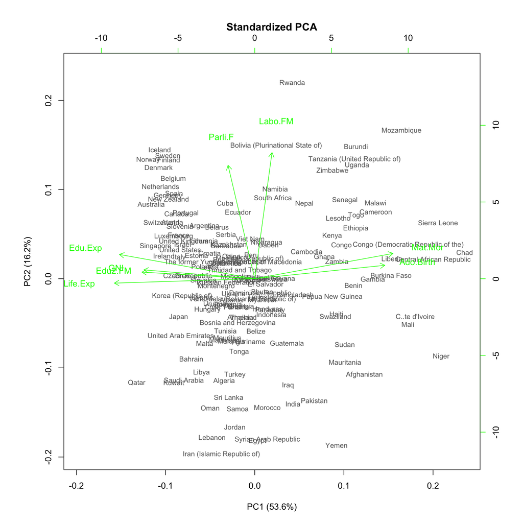

```r
# create object pc_lab to be used as axis labels
pc_lab2 <- paste0(names(pca_pr2), " (", pca_pr2, "%)")
# draw a biplot
biplot(pca_hum2, cex = c(0.8, 1), col = c("grey40", "green"), xlab = pc_lab2[1], ylab =pc_lab2[2], main="Standardized PCA")
```

### TEA dataset

Tea dataset contains 36 variables and 300 observations about individuals?? habits of drinking tea and some personal background information. Figure 5. describes the dataset visually. All other variables are categorial expect quantative age variable. There can be seen clear differences between categories in many variables: for example most of the individuals drink tea at home and only few somewhere else, and only few people drink tea during lunch.

```r
# explore dim and structure
data(tea)
str(tea)
```

```
## 'data.frame':    300 obs. of  36 variables:
##  $ breakfast       : Factor w/ 2 levels "breakfast","Not.breakfast": 1 1 2 2 1 2 1 2 1 1 ...
##  $ tea.time        : Factor w/ 2 levels "Not.tea time",..: 1 1 2 1 1 1 2 2 2 1 ...
##  $ evening         : Factor w/ 2 levels "evening","Not.evening": 2 2 1 2 1 2 2 1 2 1 ...
##  $ lunch           : Factor w/ 2 levels "lunch","Not.lunch": 2 2 2 2 2 2 2 2 2 2 ...
##  $ dinner          : Factor w/ 2 levels "dinner","Not.dinner": 2 2 1 1 2 1 2 2 2 2 ...
##  $ always          : Factor w/ 2 levels "always","Not.always": 2 2 2 2 1 2 2 2 2 2 ...
##  $ home            : Factor w/ 2 levels "home","Not.home": 1 1 1 1 1 1 1 1 1 1 ...
##  $ work            : Factor w/ 2 levels "Not.work","work": 1 1 2 1 1 1 1 1 1 1 ...
##  $ tearoom         : Factor w/ 2 levels "Not.tearoom",..: 1 1 1 1 1 1 1 1 1 2 ...
##  $ friends         : Factor w/ 2 levels "friends","Not.friends": 2 2 1 2 2 2 1 2 2 2 ...
##  $ resto           : Factor w/ 2 levels "Not.resto","resto": 1 1 2 1 1 1 1 1 1 1 ...
##  $ pub             : Factor w/ 2 levels "Not.pub","pub": 1 1 1 1 1 1 1 1 1 1 ...
##  $ Tea             : Factor w/ 3 levels "black","Earl Grey",..: 1 1 2 2 2 2 2 1 2 1 ...
##  $ How             : Factor w/ 4 levels "alone","lemon",..: 1 3 1 1 1 1 1 3 3 1 ...
```

[output cut: 22 more lines]

```r
dim(tea)
```

```
## [1] 300  36
```

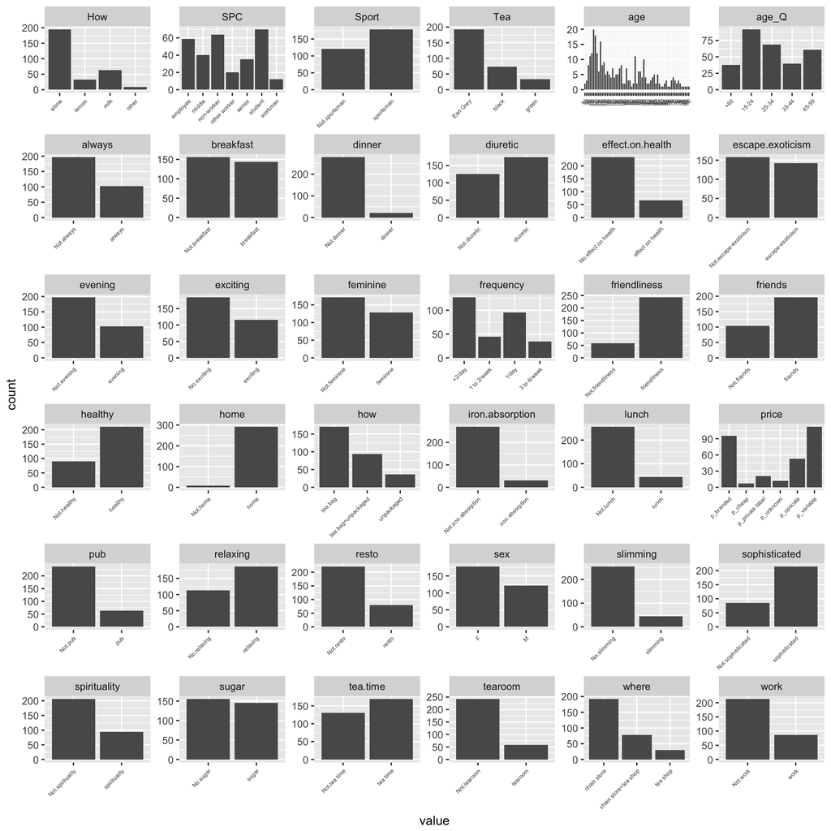

```r
# visualize the dataset
gather(tea) %>% ggplot(aes(value)) + facet_wrap("key", scales = "free") + geom_bar() + theme(axis.text.x = element_text(angle = 45, hjust = 1, size = 5))
```

Figure 5. Description of Tea variables

### Multiple Correspondence Analysis (MCA)

Multiple Correspondence Analysis (MCA) is another dimension reduction technique that can be used to analyse the patterns of several for categorial variables. I chose following variables for further analysis:

-Tea: most used type of tea (black, green, earl grey)

-tea.time: does the individual have a specific tea time or not

-How: how he/she prefers to drink the tea (alone, with milk, lemon or other)

-sex: gender

```r
# column names to keep in the dataset
keep_columns <- c("Tea", "tea.time", "How", "sex")
# select the 'keep_columns' to create a new dataset
tea2 <- subset(tea, select= keep_columns)
# multiple correspondence analysis
mca <- MCA(tea2, graph = FALSE)
# summary of the model
summary(mca)
```

```
##
## Call:
## MCA(X = tea2, graph = FALSE)
##
##
## Eigenvalues
##                        Dim.1   Dim.2   Dim.3   Dim.4   Dim.5   Dim.6
## Variance               0.340   0.305   0.263   0.247   0.225   0.207
## % of var.             19.431  17.419  15.043  14.139  12.848  11.845
## Cumulative % of var.  19.431  36.850  51.893  66.031  78.879  90.724
##                        Dim.7
## Variance               0.162
## % of var.              9.276
## Cumulative % of var. 100.000
##
## Individuals (the 10 first)
##                 Dim.1    ctr   cos2    Dim.2    ctr   cos2    Dim.3    ctr
## 1            |  0.710  0.495  0.318 |  0.565  0.349  0.201 | -0.187  0.044
## 2            |  0.191  0.036  0.017 |  0.771  0.649  0.270 |  0.128  0.021
## 3            | -0.613  0.368  0.588 | -0.420  0.193  0.276 | -0.185  0.043
## 4            |  0.670  0.441  0.468 | -0.231  0.058  0.056 |  0.074  0.007
## 5            |  0.670  0.441  0.468 | -0.231  0.058  0.056 |  0.074  0.007
## 6            |  0.670  0.441  0.468 | -0.231  0.058  0.056 |  0.074  0.007
## 7            |  0.012  0.000  0.000 | -0.151  0.025  0.027 |  0.058  0.004
## 8            | -0.467  0.214  0.106 |  0.851  0.791  0.350 |  0.112  0.016
## 9            |  0.118  0.014  0.009 |  0.324  0.115  0.064 |  0.616  0.480
## 10           |  0.710  0.495  0.318 |  0.565  0.349  0.201 | -0.187  0.044
##                cos2
## 1             0.022 |
## 2             0.007 |
## 3             0.054 |
## 4             0.006 |
## 5             0.006 |
## 6             0.006 |
## 7             0.004 |
## 8             0.006 |
## 9             0.232 |
## 10            0.022 |
##
## Categories (the 10 first)
```

[output cut: 14 more lines]

```
## green         -3.895 |  -1.257  16.508   0.195  -7.642 |
## Not.tea time  -1.513 |   0.019   0.015   0.000   0.288 |
## tea time       1.513 |  -0.015   0.011   0.000  -0.288 |
## alone         -8.373 |  -0.467  13.435   0.404 -10.994 |
## lemon         -0.865 |   1.942  39.393   0.466  11.805 |
## milk           6.183 |   0.679   9.182   0.122   6.049 |
## other         10.237 |  -1.762   8.844   0.096  -5.358 |
## F             -5.045 |  -0.203   2.322   0.060  -4.240 |
##
## Categorical variables (eta2)
##                Dim.1 Dim.2 Dim.3
## Tea          | 0.206 0.601 0.247 |
## tea.time     | 0.580 0.008 0.000 |
## How          | 0.061 0.525 0.746 |
## sex          | 0.513 0.085 0.060 |
```

About 50 % of the variation is captured by first three dimensions, firs one capturing 19.4% of the variance, second one 17.4% and third one 15.0% of the variance. Individuals table shows the contribution of first 10 individuals and categories table the contribution of first 10 categories on the dimension and squared correlation of the dimension. Last table, categorial variables shows the squared correlations between the variables and dimensions. Tea time has strong squared correlation to first dimension (0.58) but practically non to dimensions two and three. Type of tea has strong squarred correlation to dimension two (0.601) and modest squared correlation to both dimensions one (0.206) and three (0.247). Preferation to how to drink the tea has strong squared correlation with dimensions three (0.746) and dim 2 (0.525), but negligible correlation with dimension one. Gender has strong squared correlation with dimension one and neglilible to dimensions two and three. First two dimensions are illustrated also in Figure 6. Other type of tea differs from rest of the categories, whereas plain tea (alone) and Earl Grey are similar.

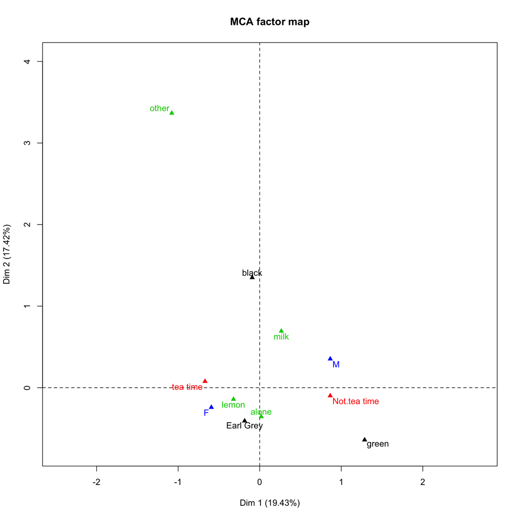

```r
# visualize MCA
plot(mca, invisible=c("ind"), habillage ="quali")
```

Figure 6. MCA